# Elsevier 2022 SDG mapping

)

)

OR

(

(

TITLE-ABS("small*-scale* fish*") AND TITLE-ABS("external* pressure*")

)

OR

(

TITLE-ABS("smallscale* fish*") AND TITLE-ABS("external* pressure*")

)

)

OR

(

(

AUTHKEY("small*-scale* fish*") AND AUTHKEY("external* pressure*")

)

OR

(

AUTHKEY("smallscale* fish*") AND AUTHKEY("external* pressure*")

)

)

OR

(

(

TITLE-ABS("small*-scale* fish*") AND TITLE-ABS("gender")

)

OR

(

TITLE-ABS("smallscale* fish*") AND TITLE-ABS("gender")

)

)

OR

(

(

AUTHKEY("small*-scale* fish*") AND AUTHKEY("gender")

)

OR

(

AUTHKEY("smallscale* fish*") AND AUTHKEY("gender")

)

)

OR

(

(

TITLE-ABS("artisanal* fish*") AND TITLE-ABS("Community-based management")

)

OR

(

TITLE-ABS("artisanal* fish*") AND TITLE-ABS("Communitybased management")

)

)

OR

(

(

AUTHKEY("artisanal* fish*") AND AUTHKEY("Community-based management")

)

OR

(

AUTHKEY("artisanal* fish*") AND AUTHKEY("Communitybased management")

)

)

OR

(

(

TITLE-ABS("small-scale fisheries") AND TITLE-ABS("Community-based management")

)

OR

(

TITLE-ABS("smallscale fisheries") AND TITLE-ABS("Communitybased management")

)

)

OR

(

(

AUTHKEY("small-scale fisheries") AND AUTHKEY("Community-based management")

)

OR

(

AUTHKEY("smallscale fisheries") AND AUTHKEY("Communitybased management")

)

)

OR

(

(

TITLE-ABS("small*-scale* fish*") AND TITLE-ABS("co-management")

)

OR

(

TITLE-ABS("smallscale* fish*") AND TITLE-ABS("comanagement")

)

)

OR

(

(

AUTHKEY("small*-scale* fish*") AND AUTHKEY("co-management")

)

OR

(

AUTHKEY("smallscale* fish*") AND AUTHKEY("comanagement")

)

)

OR

(

(

TITLE-ABS("small-scale fisheries") AND TITLE-ABS("access to resources")

)

OR

(

TITLE-ABS("smallscale fisheries") AND TITLE-ABS("access to resources")

)

)

OR

(

(

AUTHKEY("small-scale fisheries") AND AUTHKEY("access to resources")

)

OR

(

AUTHKEY("smallscale fisheries") AND AUTHKEY("access to resources")

)

)

OR

(

(

TITLE-ABS("subsistence* fish*") AND TITLE-ABS("community-based")

)

OR

(

TITLE-ABS("subsistence* fish*") AND TITLE-ABS("communitybased")

)

)

OR

(

(

AUTHKEY("subsistence* fish*") AND AUTHKEY("community-based")

)

OR

(

AUTHKEY("subsistence* fish*") AND AUTHKEY("communitybased")

)

)

OR

(

TITLE-ABS

(

"artisanal* fish*"

)

AND TITLE-ABS

(

"decision* mak*"

)

)

OR

(

AUTHKEY

(

"artisanal* fish*"

)

AND AUTHKEY

(

"decision* mak*"

)

)

OR

(

(

TITLE-ABS("small-scale fisheries") AND TITLE-ABS("Power* asymmetr*")

)

OR

(

TITLE-ABS("smallscale fisheries") AND TITLE-ABS("Power* asymmetr*")

)

)

OR

(

(

AUTHKEY("small-scale fisheries") AND AUTHKEY("Power* asymmetr*")

)

OR

(

AUTHKEY("smallscale fisheries") AND AUTHKEY("Power* asymmetr*")

)

)

OR

(

TITLE-ABS

(

"subsistence* fish*"

)

AND TITLE-ABS

(

"knowledge"

)

)

OR

(

AUTHKEY

(

"subsistence* fish*"

)

AND AUTHKEY

(

"knowledge"

)

)

OR

(

TITLE-ABS

(

"subsistence* fish*"

)

AND TITLE-ABS

(

"food security"

)

)

OR

(

AUTHKEY

(

"subsistence* fish*"

)

AND AUTHKEY

(

"food security"

)

)

OR

(

(

TITLE-ABS("small-scale fisheries") AND TITLE-ABS("access* control*")

)

OR

(

TITLE-ABS("smallscale fisheries") AND TITLE-ABS("access* control*")

)

)

OR

(

(

AUTHKEY("small-scale fisheries") AND AUTHKEY("access* control*")

)

OR

(

AUTHKEY("smallscale fisheries") AND AUTHKEY("access* control*")

)

)

OR

(

TITLE-ABS

(

"subsistence* fish*"

)

AND TITLE-ABS

(

"food security"

)

)

OR

(

AUTHKEY

(

"subsistence* fish*"

)

AND AUTHKEY

(

"food security"

)

)

OR

(

TITLE-ABS

(

"artisanal* fish*"

)

AND TITLE-ABS

(

"fisheries management"

)

)

OR

(

AUTHKEY

(

"artisanal* fish*"

)

AND AUTHKEY

(

"fisheries management"

)

)

OR

(

(

TITLE-ABS("small*-scale* fish*") AND TITLE-ABS("food security")

)

OR

(

TITLE-ABS("smallscale* fish*") AND TITLE-ABS("food security")

)

)

OR

(

(

AUTHKEY("small*-scale* fish*") AND AUTHKEY("food security")

)

OR

(

AUTHKEY("smallscale* fish*") AND AUTHKEY("food security")

)

)

OR

(

(

TITLE-ABS("small*-scale* fish*") AND TITLE-ABS("woman")

)

OR

(

TITLE-ABS("smallscale* fish*") AND TITLE-ABS("woman")

)

)

OR

(

(

AUTHKEY("small*-scale* fish*") AND AUTHKEY("woman")

)

OR

(

AUTHKEY("smallscale* fish*") AND AUTHKEY("woman")

)

)

OR

(

TITLE-ABS

(

"subsistence* fish*"

)

AND TITLE-ABS

(

"income"

)

)

OR

(

AUTHKEY

(

"subsistence* fish*"

)

AND AUTHKEY

(

"income"

)

)

OR

(

TITLE-ABS

(

"subsistence* fish*"

)

AND TITLE-ABS

(

"decision* mak*"

)

)

OR

(

AUTHKEY

(

"subsistence* fish*"

)

AND AUTHKEY

(

"decision* mak*"

)

)

OR

(

(

TITLE-ABS("Policy") OR TITLE-ABS("policies")

)

AND TITLE-ABS

(

"Small Scale Fisheries"

)

)

OR

(

(

AUTHKEY("Policy") OR AUTHKEY("policies")

)

AND AUTHKEY

(

"Small Scale Fisheries"

)

)

OR

(

(

TITLE-ABS("small-scale fisheries") AND TITLE-ABS("Interactive governance")

)

OR

(

TITLE-ABS("smallscale fisheries") AND TITLE-ABS("Interactive governance")

)

)

OR

(

(

AUTHKEY("small-scale fisheries") AND AUTHKEY("Interactive governance")

)

OR

(

AUTHKEY("smallscale fisheries") AND AUTHKEY("Interactive governance")

)

)

OR

(

TITLE-ABS

(

"artisanal* fish*"

)

AND TITLE-ABS

(

"educat*"

)

)

OR

(

AUTHKEY

(

"artisanal* fish*"

)

AND AUTHKEY

(

"educat*"

)

)

OR

(

TITLE-ABS

(

"fishing* house*"

)

AND TITLE-ABS

(

"ownership rights"

)

)

OR

(

AUTHKEY

(

"fishing* house*"

)

AND AUTHKEY

(

"ownership rights"

)

)

OR

(

(

TITLE-ABS("small*-scale* fish*") AND TITLE-ABS("sustain* livelihood*")

)

OR

(

TITLE-ABS("smallscale* fish*") AND TITLE-ABS("sustain* livelihood*")

)

)

OR

(

(

AUTHKEY("small*-scale* fish*") AND AUTHKEY("sustain* livelihood*")

)

OR

(

AUTHKEY("smallscale* fish*") AND AUTHKEY("sustain* livelihood*")

)

)

OR

(

TITLE-ABS

(

"fishing* house*"

)

AND TITLE-ABS

(

"knowledge"

)

)

OR

(

AUTHKEY

(

"fishing* house*"

)

AND AUTHKEY

(

"knowledge"

)

)

OR

(

(

TITLE-ABS("artisanal* fish*") AND TITLE-ABS("co-management")

)

OR

(

TITLE-ABS("artisanal* fish*") AND TITLE-ABS("comanagement")

)

)

OR

(

(

AUTHKEY("artisanal* fish*") AND AUTHKEY("co-management")

)

OR

(

AUTHKEY("artisanal* fish*") AND AUTHKEY("comanagement")

)

)

OR

(

TITLE-ABS

(

"artisanal* fish*"

)

AND TITLE-ABS

(

"access* to* fish*"

)

)

OR

(

AUTHKEY

(

"artisanal* fish*"

)

AND AUTHKEY

(

"access* to* fish*"

)

)

OR

(

TITLE-ABS

(

"artisanal* fish*"

)

AND TITLE-ABS

(

"sustainable* livelihood*"

)

)

OR

(

AUTHKEY

(

"artisanal* fish*"

)

AND AUTHKEY

(

"sustainable* livelihood*"

)

)

OR

(

TITLE-ABS

(

"fishing* house*"

)

AND TITLE-ABS

(

"gender"

)

)

OR

(

AUTHKEY

(

"fishing* house*"

)

AND AUTHKEY

(

"gender"

)

)

OR

(

TITLE-ABS

(

"fishing* house*"

)

AND TITLE-ABS

(

"income"

)

)

OR

(

AUTHKEY

(

"fishing* house*"

)

AND AUTHKEY

(

"income"

)

)

OR

(

TITLE-ABS

(

"artisanal* fish*"

)

AND TITLE-ABS

(

"governance"

)

)

OR

(

AUTHKEY

(

"artisanal* fish*"

)

AND AUTHKEY

(

"governance"

)

)

OR

(

TITLE-ABS

(

"subsistence* fish*"

)

AND

(

TITLE-ABS("policy") OR TITLE-ABS("policies")

)

)

OR

(

AUTHKEY

(

"subsistence* fish*"

)

AND

(

AUTHKEY("policy") OR AUTHKEY("policies")

)

)

OR

(

TITLE-ABS

(

"artisanal* fish*"

)

AND TITLE-ABS

(

"decision* power*"

)

)

OR

(

AUTHKEY

(

"artisanal* fish*"

)

AND AUTHKEY

(

"decision* power*"

)

)

OR

(

(

TITLE-ABS("small-scale fisheries") AND TITLE-ABS("decision* mak*")

)

OR

(

TITLE-ABS("smallscale fisheries") AND TITLE-ABS("decision* mak*")

)

)

OR

(

(

AUTHKEY("small-scale fisheries") AND AUTHKEY("decision* mak*")

)

OR

(

AUTHKEY("smallscale fisheries") AND AUTHKEY("decision* mak*")

)

)

OR

(

TITLE-ABS

(

"artisanal* fish*"

)

AND TITLE-ABS

(

"Interactive governance"

)

)

OR

(

AUTHKEY

(

"artisanal* fish*"

)

AND AUTHKEY

(

"Interactive governance"

)

)

OR

(

TITLE-ABS

(

"artisanal* fish*"

)

AND TITLE-ABS

(

"knowledge"

)

)

OR

(

AUTHKEY

(

"artisanal* fish*"

)

AND AUTHKEY

(

"knowledge"

)

)

OR

(

TITLE-ABS

(

"subsistence* fish*"

)

AND TITLE-ABS

(

"comanagement"

)

)

OR

(

AUTHKEY

(

"subsistence* fish*"

)

AND AUTHKEY

(

"comanagement"

)

)

OR

(

TITLE-ABS

(

"subsistence* fish*"

)

AND TITLE-ABS

(

"fisheries management"

)

)

OR

(

AUTHKEY

(

"subsistence* fish*"

)

AND AUTHKEY

(

"fisheries management"

)

)

OR

(

TITLE-ABS

(

"fishing* house*"

)

AND TITLE-ABS

(

"poverty"

)

)

OR

(

AUTHKEY

(

"fishing* house*"

)

AND AUTHKEY

(

"poverty"

)

)

OR

(

TITLE-ABS

(

"subsistence* fish*"

)

AND TITLE-ABS

(

"tragedy of the commons"

)

)

OR

(

AUTHKEY

(

"subsistence* fish*"

)

AND AUTHKEY

(

"tragedy of the commons"

)

)

OR

(

TITLE-ABS

(

"fishing* house*"

)

AND

(

TITLE-ABS("policy") OR TITLE-ABS("policies")

)

)

OR

(

AUTHKEY

(

"fishing* house*"

)

AND

(

AUTHKEY("policy") OR AUTHKEY("policies")

)

)

OR

(

(

TITLE-ABS("fishing* house*") AND TITLE-ABS("community-based")

)

OR

(

TITLE-ABS("fishing* house*") AND TITLE-ABS("communitybased")

)

)

OR

(

(

AUTHKEY("fishing* house*") AND AUTHKEY("community-based")

)

OR

(

AUTHKEY("fishing* house*") AND AUTHKEY("communitybased")

)

)

OR

(

TITLE-ABS

(

"governance"

)

AND TITLE-ABS

(

"Small Scale Fisheries"

)

)

OR

(

AUTHKEY

(

"governance"

)

AND AUTHKEY

(

"Small Scale Fisheries"

)

)

OR

(

(

TITLE-ABS("small*-scale* fish*") AND TITLE-ABS("fisheries management")

)

OR

(

TITLE-ABS("smallscale* fish*") AND TITLE-ABS("fisheries management")

)

)

OR

(

(

AUTHKEY("small*-scale* fish*") AND AUTHKEY("fisheries management")

)

OR

(

AUTHKEY("smallscale* fish*") AND AUTHKEY("fisheries management")

)

)

OR

(

TITLE-ABS

(

"fishing* house*"

)

AND TITLE-ABS

(

"comanagement"

)

)

OR

(

AUTHKEY

(

"fishing* house*"

)

AND AUTHKEY

(

"comanagement"

)

)

OR

(

(

TITLE-ABS("small-scale fisheries") AND TITLE-ABS("cooperative management")

)

OR

(

TITLE-ABS("smallscale fisheries") AND TITLE-ABS("cooperative management")

)

)

OR

(

(

AUTHKEY("small-scale fisheries") AND AUTHKEY("cooperative management")

)

OR

(

AUTHKEY("smallscale fisheries") AND AUTHKEY("cooperative management")

)

)

OR

(

TITLE-ABS

(

"fishing* house*"

)

AND TITLE-ABS

(

"food security"

)

)

OR

(

AUTHKEY

(

"fishing* house*"

)

AND AUTHKEY

(

"food security"

)

)

OR

(

(

TITLE-ABS("small-scale fisheries") AND TITLE-ABS("ownership rights")

)

OR

(

TITLE-ABS("smallscale fisheries") AND TITLE-ABS("ownership rights")

)

)

OR

(

(

AUTHKEY("small-scale fisheries") AND AUTHKEY("ownership rights")

)

OR

(

AUTHKEY("smallscale fisheries") AND AUTHKEY("ownership rights")

)

)

OR

(

TITLE-ABS

(

"subsistence* fish*"

)

AND TITLE-ABS

(

"access* to* fish*"

)

)

OR

(

AUTHKEY

(

"subsistence* fish*"

)

AND AUTHKEY

(

"access* to* fish*"

)

)

OR

(

TITLE-ABS

(

"fishing* house*"

)

AND TITLE-ABS

(

"food security"

)

)

OR

(

AUTHKEY

(

"fishing* house*"

)

AND AUTHKEY

(

"food security"

)

)

OR

(

TITLE-ABS

(

"fishing* house*"

)

AND TITLE-ABS

(

"women"

)

)

OR

(

AUTHKEY

(

"fishing* house*"

)

AND AUTHKEY

(

"women"

)

)

OR

(

TITLE-ABS

(

"artisanal* fish*"

)

AND TITLE-ABS

(

"income"

)

)

OR

(

AUTHKEY

(

"artisanal* fish*"

)

AND AUTHKEY

(

"income"

)

)

OR

(

(

TITLE-ABS("subsistence* fish*") AND TITLE-ABS("Community-based management")

)

OR

(

TITLE-ABS("subsistence* fish*") AND TITLE-ABS("Communitybased management")

)

)

OR

(

(

AUTHKEY("subsistence* fish*") AND AUTHKEY("Community-based management")

)

OR

(

AUTHKEY("subsistence* fish*") AND AUTHKEY("Communitybased management")

)

)

OR

(

TITLE-ABS

(

"artisanal* fish*"

)

AND TITLE-ABS

(

"poverty"

)

)

OR

(

AUTHKEY

(

"artisanal* fish*"

)

AND AUTHKEY

(

"poverty"

)

)

OR

(

(

TITLE-ABS("small-scale fisheries") AND TITLE-ABS("comanagement")

)

OR

(

TITLE-ABS("smallscale fisheries") AND TITLE-ABS("comanagement")

)

)

OR

(

(

AUTHKEY("small-scale fisheries") AND AUTHKEY("comanagement")

)

OR

(

AUTHKEY("smallscale fisheries") AND AUTHKEY("comanagement")

)

)

OR

(

TITLE-ABS

(

"subsistence* fish*"

)

AND TITLE-ABS

(

"gender"

)

)

OR

(

AUTHKEY

(

"subsistence* fish*"

)

AND AUTHKEY

(

"gender"

)

)

OR

(

(

TITLE-ABS("small-scale fisheries") AND TITLE-ABS("poverty")

)

OR

(

TITLE-ABS("smallscale fisheries") AND TITLE-ABS("poverty")

)

)

OR

(

(

AUTHKEY("small-scale fisheries") AND AUTHKEY("poverty")

)

OR

(

AUTHKEY("smallscale fisheries") AND AUTHKEY("poverty")

)

)

OR

(

TITLE-ABS

(

"small-scale fisheries governance"

)

OR TITLE-ABS

(

"smallscale fisheries governance"

)

)

OR

(

AUTHKEY

(

"small-scale fisheries governance"

)

OR AUTHKEY

(

"smallscale fisheries governance"

)

)

OR

(

TITLE-ABS

(

"subsistence* fish*"

)

AND TITLE-ABS

(

"sustainable* livelihood*"

)

)

OR

(

AUTHKEY

(

"subsistence* fish*"

)

AND AUTHKEY

(

"sustainable* livelihood*"

)

)

OR

(

TITLE-ABS

(

"artisanal* fish*"

)

AND TITLE-ABS

(

"women"

)

)

OR

(

AUTHKEY

(

"artisanal* fish*"

)

AND AUTHKEY

(

"women"

)

)

OR

(

(

TITLE-ABS("small-scale fisheries") AND TITLE-ABS("access to infrastructure")

)

OR

(

TITLE-ABS("smallscale fisheries") AND TITLE-ABS("access to infrastructure")

)

)

OR

(

(

AUTHKEY("small-scale fisheries") AND AUTHKEY("access to infrastructure")

)

OR

(

AUTHKEY("smallscale fisheries") AND AUTHKEY("access to infrastructure")

)

)

OR

(

TITLE-ABS

(

"governance of small-scale fisheries"

)

OR TITLE-ABS

(

"governance of smallscale fisheries"

)

)

OR

(

AUTHKEY

(

"governance of small-scale fisheries"

)

OR AUTHKEY

(

"governance of smallscale fisheries"

)

)

)

)

OR

(

(

(

TITLE-ABS

(

"Deep Seabed Mining Act"

)

OR AUTHKEY

(

"Deep Seabed Mining Act"

)

OR TITLE-ABS

(

"Convention for the Conservation of Antarctic Marine Living Resources"

)

OR AUTHKEY

(

"Convention for the Conservation of Antarctic Marine Living Resources"

)

OR TITLE-ABS

(

"Nauru Agreement"

)

OR AUTHKEY

(

"Nauru Agreement"

)

OR

(

TITLE-ABS("International Convention on Oil Pollution Preparedness, Response and Co-operation") OR TITLE-ABS("International Convention on Oil Pollution Preparedness, Response and Cooperation")

)

OR

(

AUTHKEY("International Convention on Oil Pollution Preparedness, Response and Co-operation") OR AUTHKEY("International Convention on Oil Pollution Preparedness, Response and Cooperation")

)

OR

(

(TITLE-ABS("ocean*") OR TITLE-ABS("marine") OR TITLE-ABS("coast*") OR TITLE-ABS("sea") OR TITLE-ABS("seas") OR TITLE-ABS("coral* reef*")) AND (TITLE-ABS("sustainab*") OR TITLE-ABS("preserv**") OR TITLE-ABS("conserv*") OR TITLE-ABS("protect*")) AND TITLE-ABS("international standard")

)

OR

(

(AUTHKEY("ocean*") OR AUTHKEY("marine") OR AUTHKEY("coast*") OR AUTHKEY("sea") OR AUTHKEY("seas") OR AUTHKEY("coral* reef*")) AND (AUTHKEY("sustainab*") OR AUTHKEY("preserv**") OR AUTHKEY("conserv*") OR AUTHKEY("protect*")) AND AUTHKEY("international standard")

)

OR TITLE-ABS

(

"Convention for the Conservation and Management of Highly Migratory Fish Stocks"

)

OR AUTHKEY

(

"Convention for the Conservation and Management of Highly Migratory Fish Stocks"

)

OR TITLE-ABS

(

"Commission for the Conservation of Antarctic Marine Living Resources"

)

OR AUTHKEY

(

"Commission for the Conservation of Antarctic Marine Living Resources"

)

OR

(

(TITLE-ABS("ocean*") OR TITLE-ABS("marine") OR TITLE-ABS("coast*") OR TITLE-ABS("sea") OR TITLE-ABS("seas") OR TITLE-ABS("coral* reef*")) AND (TITLE-ABS("sustainab*") OR TITLE-ABS("preserv**") OR TITLE-ABS("conserv*") OR TITLE-ABS("protect*")) AND TITLE-ABS("International Plan of Action")

)

OR

(

(AUTHKEY("ocean*") OR AUTHKEY("marine") OR AUTHKEY("coast*") OR AUTHKEY("sea") OR AUTHKEY("seas") OR AUTHKEY("coral* reef*")) AND (AUTHKEY("sustainab*") OR AUTHKEY("preserv**") OR AUTHKEY("conserv*") OR AUTHKEY("protect*")) AND AUTHKEY("International Plan of Action")

)

OR

(

(TITLE-ABS("ocean*") OR TITLE-ABS("marine") OR TITLE-ABS("coast*") OR TITLE-ABS("sea") OR TITLE-ABS("seas") OR TITLE-ABS("coral* reef*")) AND (TITLE-ABS("sustainab*") OR TITLE-ABS("preserv**") OR TITLE-ABS("conserv*") OR TITLE-ABS("protect*")) AND TITLE-ABS(" International Tribunal for the Law of the Sea")

)

OR

(

(AUTHKEY("ocean*") OR AUTHKEY("marine") OR AUTHKEY("coast*") OR AUTHKEY("sea") OR AUTHKEY("seas") OR AUTHKEY("coral* reef*")) AND (AUTHKEY("sustainab*") OR AUTHKEY("preserv**") OR AUTHKEY("conserv*") OR AUTHKEY("protect*")) AND AUTHKEY(" International Tribunal for the Law of the Sea")

)

OR TITLE-ABS

(

"International Convention on Civil Liability for Bunker Oil Pollution Damage"

)

OR AUTHKEY

(

"International Convention on Civil Liability for Bunker Oil Pollution Damage"

)

OR TITLE-ABS

(

"Work in Fishing Convention, 2007"

)

OR AUTHKEY

(

"Work in Fishing Convention, 2007"

)

OR

(

(TITLE-ABS("ocean*") OR TITLE-ABS("marine") OR TITLE-ABS("coast*") OR TITLE-ABS("sea") OR TITLE-ABS("seas") OR TITLE-ABS("coral* reef*")) AND (TITLE-ABS("sustainab*") OR TITLE-ABS("preserv**") OR TITLE-ABS("conserv*") OR TITLE-ABS("protect*")) AND TITLE-ABS("legal system")

)

OR

(

(AUTHKEY("ocean*") OR AUTHKEY("marine") OR AUTHKEY("coast*") OR AUTHKEY("sea") OR AUTHKEY("seas") OR AUTHKEY("coral* reef*")) AND (AUTHKEY("sustainab*") OR AUTHKEY("preserv**") OR AUTHKEY("conserv*") OR AUTHKEY("protect*")) AND AUTHKEY("legal system")

)

OR TITLE-ABS

(

"UN fish stocks agreement"

)

OR AUTHKEY

(

"UN fish stocks agreement"

)

OR

(

(TITLE-ABS("ocean*") OR TITLE-ABS("marine") OR TITLE-ABS("coast*") OR TITLE-ABS("sea") OR TITLE-ABS("seas") OR TITLE-ABS("coral* reef*")) AND (TITLE-ABS("sustainab*") OR TITLE-ABS("preserv**") OR TITLE-ABS("conserv*") OR TITLE-ABS("protect*")) AND TITLE-ABS("International Commission")

)

OR

(

(AUTHKEY("ocean*") OR AUTHKEY("marine") OR AUTHKEY("coast*") OR AUTHKEY("sea") OR AUTHKEY("seas") OR AUTHKEY("coral* reef*")) AND (AUTHKEY("sustainab*") OR AUTHKEY("preserv**") OR AUTHKEY("conserv*") OR AUTHKEY("protect*")) AND AUTHKEY("International Commission")

)

OR TITLE-ABS

(

"Fishery Commission"

)

OR AUTHKEY

(

"Fishery Commission"

)

OR

(

(TITLE-ABS("ocean*") OR TITLE-ABS("marine") OR TITLE-ABS("coast*") OR TITLE-ABS("sea") OR TITLE-ABS("seas") OR TITLE-ABS("coral* reef*")) AND (TITLE-ABS("sustainab*") OR TITLE-ABS("preserv**") OR TITLE-ABS("conserv*") OR TITLE-ABS("protect*")) AND TITLE-ABS("sponsor* state*")

)

OR

(

(AUTHKEY("ocean*") OR AUTHKEY("marine") OR AUTHKEY("coast*") OR AUTHKEY("sea") OR AUTHKEY("seas") OR AUTHKEY("coral* reef*")) AND (AUTHKEY("sustainab*") OR AUTHKEY("preserv**") OR AUTHKEY("conserv*") OR AUTHKEY("protect*")) AND AUTHKEY("sponsor* state*")

)

OR TITLE-ABS

(

"Straddling Fish Stocks Agreement"

)

OR AUTHKEY

(

"Straddling Fish Stocks Agreement"

)

OR TITLE-ABS

(

"Southern Indian Ocean Fisheries Agreement"

)

OR AUTHKEY

(

"Southern Indian Ocean Fisheries Agreement"

)

OR

(

(TITLE-ABS("ocean*") OR TITLE-ABS("marine") OR TITLE-ABS("coast*") OR TITLE-ABS("sea") OR TITLE-ABS("seas") OR TITLE-ABS("coral* reef*")) AND (TITLE-ABS("sustainab*") OR TITLE-ABS("preserv**") OR TITLE-ABS("conserv*") OR TITLE-ABS("protect*")) AND TITLE-ABS("prohibition")

)

OR

(

(AUTHKEY("ocean*") OR AUTHKEY("marine") OR AUTHKEY("coast*") OR AUTHKEY("sea") OR AUTHKEY("seas") OR AUTHKEY("coral* reef*")) AND (AUTHKEY("sustainab*") OR AUTHKEY("preserv**") OR AUTHKEY("conserv*") OR AUTHKEY("protect*")) AND AUTHKEY("prohibition")

)

OR TITLE-ABS

(

"South Pacific Tuna Treaty"

)

OR AUTHKEY

(

"South Pacific Tuna Treaty"

)

OR

(

(TITLE-ABS("ocean*") OR TITLE-ABS("marine") OR TITLE-ABS("coast*") OR TITLE-ABS("sea") OR TITLE-ABS("seas") OR TITLE-ABS("coral* reef*")) AND (TITLE-ABS("sustainab*") OR TITLE-ABS("preserv**") OR TITLE-ABS("conserv*") OR TITLE-ABS("protect*")) AND TITLE-ABS("legal regime")

)

OR

(

(AUTHKEY("ocean*") OR AUTHKEY("marine") OR AUTHKEY("coast*") OR AUTHKEY("sea") OR AUTHKEY("seas") OR AUTHKEY("coral* reef*")) AND (AUTHKEY("sustainab*") OR AUTHKEY("preserv**") OR AUTHKEY("conserv*") OR AUTHKEY("protect*")) AND AUTHKEY("legal regime")

)

OR TITLE-ABS

(

"Fisheries Convention"

)

OR AUTHKEY

(

"Fisheries Convention"

)

OR TITLE-ABS

(

"North Pacific Anadromous Fish Commission "

)

OR AUTHKEY

(

"North Pacific Anadromous Fish Commission "

)

OR

(

TITLE-ABS("STCW-F Convention") OR TITLE-ABS("STCWF Convention")

)

OR

(

AUTHKEY("STCW-F Convention") OR AUTHKEY("STCWF Convention")

)

OR TITLE-ABS

(

"Convention on the Conservation and Management of Highly Migratory Fish Stocks in the Western and Central Pacific Ocean"

)

OR AUTHKEY

(

"Convention on the Conservation and Management of Highly Migratory Fish Stocks in the Western and Central Pacific Ocean"

)

OR TITLE-ABS

(

"International Commission for the Conservation of Atlantic Tuna"

)

OR AUTHKEY

(

"International Commission for the Conservation of Atlantic Tuna"

)

OR TITLE-ABS

(

"International Convention on the Establishment of an International Fund for Compensation for Oil Pollution Damage"

)

OR AUTHKEY

(

"International Convention on the Establishment of an International Fund for Compensation for Oil Pollution Damage"

)

OR TITLE-ABS

(

"International Convention on Civil Liability for Oil Pollution Damage"

)

OR AUTHKEY

(

"International Convention on Civil Liability for Oil Pollution Damage"

)

OR TITLE-ABS

(

"Convention on the Conservation and Management of Fishery Resources in the South East Atlantic Ocean"

)

OR AUTHKEY

(

"Convention on the Conservation and Management of Fishery Resources in the South East Atlantic Ocean"

)

OR TITLE-ABS

(

"Framework Convention for the Protection of the Marine Environment of the Caspian Sea"

)

OR AUTHKEY

(

"Framework Convention for the Protection of the Marine Environment of the Caspian Sea"

)

OR

(

(TITLE-ABS("ocean*") OR TITLE-ABS("marine") OR TITLE-ABS("coast*") OR TITLE-ABS("sea") OR TITLE-ABS("seas") OR TITLE-ABS("coral* reef*")) AND (TITLE-ABS("sustainab*") OR TITLE-ABS("preserv**") OR TITLE-ABS("conserv*") OR TITLE-ABS("protect*")) AND TITLE-ABS("arbitration")

)

OR

(

(AUTHKEY("ocean*") OR AUTHKEY("marine") OR AUTHKEY("coast*") OR AUTHKEY("sea") OR AUTHKEY("seas") OR AUTHKEY("coral* reef*")) AND (AUTHKEY("sustainab*") OR AUTHKEY("preserv**") OR AUTHKEY("conserv*") OR AUTHKEY("protect*")) AND AUTHKEY("arbitration")

)

OR

(

(TITLE-ABS("ocean*") OR TITLE-ABS("marine") OR TITLE-ABS("coast*") OR TITLE-ABS("sea") OR TITLE-ABS("seas") OR TITLE-ABS("coral* reef*")) AND (TITLE-ABS("sustainab*") OR TITLE-ABS("preserv**") OR TITLE-ABS("conserv*") OR TITLE-ABS("protect*")) AND TITLE-ABS("bilateral* agreement*")

)

OR

(

(AUTHKEY("ocean*") OR AUTHKEY("marine") OR AUTHKEY("coast*") OR AUTHKEY("sea") OR AUTHKEY("seas") OR AUTHKEY("coral* reef*")) AND (AUTHKEY("sustainab*") OR AUTHKEY("preserv**") OR AUTHKEY("conserv*") OR AUTHKEY("protect*")) AND AUTHKEY("bilateral* agreement*")

)

OR

(

TITLE-ABS("Marine* genetic* resource*") AND (TITLE-ABS("law") OR TITLE-ABS("laws") OR TITLE-ABS("treaty") OR TITLE-ABS("treaties") OR TITLE-ABS("regulation") OR TITLE-ABS("regulations") OR TITLE-ABS("policy") OR TITLE-ABS("policies") OR TITLE-ABS("jurisdiction") OR TITLE-ABS("UNCLOS") OR TITLE-ABS("law of the sea") OR TITLE-ABS("legal"))

)

OR

(

AUTHKEY("Marine* genetic* resource*") AND (AUTHKEY("law") OR AUTHKEY("laws") OR AUTHKEY("treaty") OR AUTHKEY("treaties") OR AUTHKEY("regulation") OR AUTHKEY("regulations") OR AUTHKEY("policy") OR AUTHKEY("policies") OR AUTHKEY("jurisdiction") OR AUTHKEY("UNCLOS") OR AUTHKEY("law of the sea") OR AUTHKEY("legal"))

)

OR

(

(TITLE-ABS("ocean*") OR TITLE-ABS("marine") OR TITLE-ABS("coast*") OR TITLE-ABS("sea") OR TITLE-ABS("seas") OR TITLE-ABS("coral* reef*")) AND (TITLE-ABS("sustainab*") OR TITLE-ABS("preserv**") OR TITLE-ABS("conserv*") OR TITLE-ABS("protect*")) AND TITLE-ABS("international standards")

)

OR

(

(AUTHKEY("ocean*") OR AUTHKEY("marine") OR AUTHKEY("coast*") OR AUTHKEY("sea") OR AUTHKEY("seas") OR AUTHKEY("coral* reef*")) AND (AUTHKEY("sustainab*") OR AUTHKEY("preserv**") OR AUTHKEY("conserv*") OR AUTHKEY("protect*")) AND AUTHKEY("international standards")

)

OR

(

(TITLE-ABS("ocean*") OR TITLE-ABS("marine") OR TITLE-ABS("coast*") OR TITLE-ABS("sea") OR TITLE-ABS("seas") OR TITLE-ABS("coral* reef*")) AND (TITLE-ABS("sustainab*") OR TITLE-ABS("preserv**") OR TITLE-ABS("conserv*") OR TITLE-ABS("protect*")) AND TITLE-ABS("legal obligation")

)

OR

(

(AUTHKEY("ocean*") OR AUTHKEY("marine") OR AUTHKEY("coast*") OR AUTHKEY("sea") OR AUTHKEY("seas") OR AUTHKEY("coral* reef*")) AND (AUTHKEY("sustainab*") OR AUTHKEY("preserv**") OR AUTHKEY("conserv*") OR AUTHKEY("protect*")) AND AUTHKEY("legal obligation")

)

OR

(

TITLE-ABS("coastal* disaster*") AND (TITLE-ABS("law") OR TITLE-ABS("laws") OR TITLE-ABS("treaty") OR TITLE-ABS("treaties") OR TITLE-ABS("regulation") OR TITLE-ABS("regulations") OR TITLE-ABS("policy") OR TITLE-ABS("policies") OR TITLE-ABS("jurisdiction") OR TITLE-ABS("UNCLOS") OR TITLE-ABS("law of the sea") OR TITLE-ABS("legal"))

)

OR

(

AUTHKEY("coastal* disaster*") AND (AUTHKEY("law") OR AUTHKEY("laws") OR AUTHKEY("treaty") OR AUTHKEY("treaties") OR AUTHKEY("regulation") OR AUTHKEY("regulations") OR AUTHKEY("policy") OR AUTHKEY("policies") OR AUTHKEY("jurisdiction") OR AUTHKEY("UNCLOS") OR AUTHKEY("law of the sea") OR AUTHKEY("legal"))

)

OR TITLE-ABS

(

"STOPIA"

)

OR AUTHKEY

(

"STOPIA"

)

OR

(

TITLE-ABS("Global Programme of Action for the Protection of the Marine Environment from Land-based Activities") OR TITLE-ABS("Global Programme of Action for the Protection of the Marine Environment from Landbased Activities")

)

OR

(

AUTHKEY("Global Programme of Action for the Protection of the Marine Environment from Land-based Activities") OR AUTHKEY("Global Programme of Action for the Protection of the Marine Environment from Landbased Activities")

)

OR TITLE-ABS

(

"International Seabed Authority"

)

OR AUTHKEY

(

"International Seabed Authority"

)

OR

(

(TITLE-ABS("ocean*") OR TITLE-ABS("marine") OR TITLE-ABS("coast*") OR TITLE-ABS("sea") OR TITLE-ABS("seas") OR TITLE-ABS("coral* reef*")) AND (TITLE-ABS("sustainab*") OR TITLE-ABS("preserv**") OR TITLE-ABS("conserv*") OR TITLE-ABS("protect*")) AND TITLE-ABS("UN Convention on the Law of the Sea")

)

OR

(

(AUTHKEY("ocean*") OR AUTHKEY("marine") OR AUTHKEY("coast*") OR AUTHKEY("sea") OR AUTHKEY("seas") OR AUTHKEY("coral* reef*")) AND (AUTHKEY("sustainab*") OR AUTHKEY("preserv**") OR AUTHKEY("conserv*") OR AUTHKEY("protect*")) AND AUTHKEY("UN Convention on the Law of the Sea")

)

OR TITLE-ABS

(

"MARPOL"

)

OR AUTHKEY

(

"MARPOL"

)

OR TITLE-ABS

(

"Action Plan for the Protection, Management and Development of the Marine and Coastal Environment of the Northwest Pacific Region"

)

OR AUTHKEY

(

"Action Plan for the Protection, Management and Development of the Marine and Coastal Environment of the Northwest Pacific Region"

)

OR

(

(TITLE-ABS("ocean*") OR TITLE-ABS("marine") OR TITLE-ABS("coast* ecosystem*") OR TITLE-ABS("coast* environment*") OR TITLE-ABS("sea") OR TITLE-ABS("seas") OR TITLE-ABS("coral* reef*")) AND (TITLE-ABS("sustainab*") OR TITLE-ABS("preserv**") OR TITLE-ABS("conserv*") OR TITLE-ABS("protect*")) AND TITLE-ABS("legislation")

)

OR

(

(AUTHKEY("ocean*") OR AUTHKEY("marine") OR AUTHKEY("coast* ecosystem*") OR AUTHKEY("coast* environment*") OR AUTHKEY("sea") OR AUTHKEY("seas") OR AUTHKEY("coral* reef*")) AND (AUTHKEY("sustainab*") OR AUTHKEY("preserv**") OR AUTHKEY("conserv*") OR AUTHKEY("protect*")) AND AUTHKEY("legislation")

)

OR

(

(TITLE-ABS("ocean*") OR TITLE-ABS("marine") OR TITLE-ABS("coast*") OR TITLE-ABS("sea") OR TITLE-ABS("seas") OR TITLE-ABS("coral* reef*")) AND (TITLE-ABS("sustainab*") OR TITLE-ABS("preserv**") OR TITLE-ABS("conserv*") OR TITLE-ABS("protect*")) AND TITLE-ABS("legal* act*")

)

OR

(

(AUTHKEY("ocean*") OR AUTHKEY("marine") OR AUTHKEY("coast*") OR AUTHKEY("sea") OR AUTHKEY("seas") OR AUTHKEY("coral* reef*")) AND (AUTHKEY("sustainab*") OR AUTHKEY("preserv**") OR AUTHKEY("conserv*") OR AUTHKEY("protect*")) AND AUTHKEY("legal* act*")

)

OR

(

(TITLE-ABS("ocean*") OR TITLE-ABS("marine") OR TITLE-ABS("coast*") OR TITLE-ABS("sea") OR TITLE-ABS("seas") OR TITLE-ABS("coral* reef*")) AND (TITLE-ABS("sustainab*") OR TITLE-ABS("preserv**") OR TITLE-ABS("conserv*") OR TITLE-ABS("protect*")) AND (TITLE-ABS("international policy") OR TITLE-ABS("international policies"))

)

OR

(

(AUTHKEY("ocean*") OR AUTHKEY("marine") OR AUTHKEY("coast*") OR AUTHKEY("sea") OR AUTHKEY("seas") OR AUTHKEY("coral* reef*")) AND (AUTHKEY("sustainab*") OR AUTHKEY("preserv**") OR AUTHKEY("conserv*") OR AUTHKEY("protect*")) AND (AUTHKEY("international policy") OR AUTHKEY("international policies"))

)

OR

(

(TITLE-ABS("ocean*") OR TITLE-ABS("marine") OR TITLE-ABS("coast*") OR TITLE-ABS("sea") OR TITLE-ABS("seas") OR TITLE-ABS("coral* reef*")) AND (TITLE-ABS("sustainab*") OR TITLE-ABS("preserv**") OR TITLE-ABS("conserv*") OR TITLE-ABS("protect*")) AND TITLE-ABS("UNCLOS")

)

OR

(

(AUTHKEY("ocean*") OR AUTHKEY("marine") OR AUTHKEY("coast*") OR AUTHKEY("sea") OR AUTHKEY("seas") OR AUTHKEY("coral* reef*")) AND (AUTHKEY("sustainab*") OR AUTHKEY("preserv**") OR AUTHKEY("conserv*") OR AUTHKEY("protect*")) AND AUTHKEY("UNCLOS")

)

OR

(

TITLE-ABS("ocean* resource*") AND (TITLE-ABS("law") OR TITLE-ABS("laws") OR TITLE-ABS("treaty") OR TITLE-ABS("treaties") OR TITLE-ABS("regulation") OR TITLE-ABS("regulations") OR TITLE-ABS("policy") OR TITLE-ABS("policies") OR TITLE-ABS("jurisdiction") OR TITLE-ABS("UNCLOS") OR TITLE-ABS("law of the sea") OR TITLE-ABS("legal"))

)

OR

(

AUTHKEY("ocean* resource*") AND (AUTHKEY("law") OR AUTHKEY("laws") OR AUTHKEY("treaty") OR AUTHKEY("treaties") OR AUTHKEY("regulation") OR AUTHKEY("regulations") OR AUTHKEY("policy") OR AUTHKEY("policies") OR AUTHKEY("jurisdiction") OR AUTHKEY("UNCLOS") OR AUTHKEY("law of the sea") OR AUTHKEY("legal"))

)

OR TITLE-ABS

(

"International Convention for the Prevention of Pollution from Ships"

)

OR AUTHKEY

(

"International Convention for the Prevention of Pollution from Ships"

)

OR

(

(TITLE-ABS("ocean*") OR TITLE-ABS("marine") OR TITLE-ABS("coast* ecosystem*") OR TITLE-ABS("coast* environment*") OR TITLE-ABS("sea") OR TITLE-ABS("seas") OR TITLE-ABS("coral* reef*")) AND (TITLE-ABS("sustainab*") OR TITLE-ABS("preserv**") OR TITLE-ABS("conserv*") OR TITLE-ABS("protect*")) AND TITLE-ABS("jurisdiction")

)

OR

(

(AUTHKEY("ocean*") OR AUTHKEY("marine") OR AUTHKEY("coast* ecosystem*") OR AUTHKEY("coast* environment*") OR AUTHKEY("sea") OR AUTHKEY("seas") OR AUTHKEY("coral* reef*")) AND (AUTHKEY("sustainab*") OR AUTHKEY("preserv**") OR AUTHKEY("conserv*") OR AUTHKEY("protect*")) AND AUTHKEY("jurisdiction")

)

OR

(

(TITLE-ABS("ocean*") OR TITLE-ABS("marine") OR TITLE-ABS("coast*") OR TITLE-ABS("sea") OR TITLE-ABS("seas") OR TITLE-ABS("coral* reef*")) AND (TITLE-ABS("sustainab*") OR TITLE-ABS("preserv**") OR TITLE-ABS("conserv*") OR TITLE-ABS("protect*")) AND TITLE-ABS("legal regimes")

)

OR

(

(AUTHKEY("ocean*") OR AUTHKEY("marine") OR AUTHKEY("coast*") OR AUTHKEY("sea") OR AUTHKEY("seas") OR AUTHKEY("coral* reef*")) AND (AUTHKEY("sustainab*") OR AUTHKEY("preserv**") OR AUTHKEY("conserv*") OR AUTHKEY("protect*")) AND AUTHKEY("legal regimes")

)

OR

(

TITLE-ABS("ocean disposal") AND (TITLE-ABS("law") OR TITLE-ABS("laws") OR TITLE-ABS("treaty") OR TITLE-ABS("treaties") OR TITLE-ABS("regulation") OR TITLE-ABS("regulations") OR TITLE-ABS("policy") OR TITLE-ABS("policies") OR TITLE-ABS("jurisdiction") OR TITLE-ABS("UNCLOS") OR TITLE-ABS("law of the sea") OR TITLE-ABS("legal"))

)

OR

(

AUTHKEY("ocean disposal") AND (AUTHKEY("law") OR AUTHKEY("laws") OR AUTHKEY("treaty") OR AUTHKEY("treaties") OR AUTHKEY("regulation") OR AUTHKEY("regulations") OR AUTHKEY("policy") OR AUTHKEY("policies") OR AUTHKEY("jurisdiction") OR AUTHKEY("UNCLOS") OR AUTHKEY("law of the sea") OR AUTHKEY("legal"))

)

OR

(

(TITLE-ABS("ocean*") OR TITLE-ABS("marine") OR TITLE-ABS("coast*") OR TITLE-ABS("sea") OR TITLE-ABS("seas") OR TITLE-ABS("coral* reef*")) AND (TITLE-ABS("sustainab*") OR TITLE-ABS("preserv**") OR TITLE-ABS("conserv*") OR TITLE-ABS("protect*")) AND (TITLE-ABS("international law") OR TITLE-ABS("international laws"))

)

OR

(

(AUTHKEY("ocean*") OR AUTHKEY("marine") OR AUTHKEY("coast*") OR AUTHKEY("sea") OR AUTHKEY("seas") OR AUTHKEY("coral* reef*")) AND (AUTHKEY("sustainab*") OR AUTHKEY("preserv**") OR AUTHKEY("conserv*") OR AUTHKEY("protect*")) AND (AUTHKEY("international law") OR AUTHKEY("international laws"))

)

OR TITLE-ABS

(

"integrated coastal management legislation"

)

OR AUTHKEY

(

"integrated coastal management legislation"

)

OR

(

(TITLE-ABS("ocean*") OR TITLE-ABS("marine") OR TITLE-ABS("coast*") OR TITLE-ABS("sea") OR TITLE-ABS("seas") OR TITLE-ABS("coral* reef*")) AND (TITLE-ABS("sustainab*") OR TITLE-ABS("preserv**") OR TITLE-ABS("conserv*") OR TITLE-ABS("protect*")) AND TITLE-ABS("Programme of Action")

)

OR

(

(AUTHKEY("ocean*") OR AUTHKEY("marine") OR AUTHKEY("coast*") OR AUTHKEY("sea") OR AUTHKEY("seas") OR AUTHKEY("coral* reef*")) AND (AUTHKEY("sustainab*") OR AUTHKEY("preserv**") OR AUTHKEY("conserv*") OR AUTHKEY("protect*")) AND AUTHKEY("Programme of Action")

)

OR

(

(TITLE-ABS("ocean*") OR TITLE-ABS("marine") OR TITLE-ABS("coast*") OR TITLE-ABS("sea") OR TITLE-ABS("seas") OR TITLE-ABS("coral* reef*")) AND (TITLE-ABS("sustainab*") OR TITLE-ABS("preserv**") OR TITLE-ABS("conserv*") OR TITLE-ABS("protect*")) AND TITLE-ABS("Convention on the Law of the Sea")

)

OR

(

(AUTHKEY("ocean*") OR AUTHKEY("marine") OR AUTHKEY("coast*") OR AUTHKEY("sea") OR AUTHKEY("seas") OR AUTHKEY("coral* reef*")) AND (AUTHKEY("sustainab*") OR AUTHKEY("preserv**") OR AUTHKEY("conserv*") OR AUTHKEY("protect*")) AND AUTHKEY("Convention on the Law of the Sea")

)

OR

(

TITLE-ABS("ocean dumping") AND (TITLE-ABS("law") OR TITLE-ABS("laws") OR TITLE-ABS("treaty") OR TITLE-ABS("treaties") OR TITLE-ABS("regulation") OR TITLE-ABS("regulations") OR TITLE-ABS("policy") OR TITLE-ABS("policies") OR TITLE-ABS("jurisdiction") OR TITLE-ABS("UNCLOS") OR TITLE-ABS("law of the sea") OR TITLE-ABS("legal"))

)

OR

(

AUTHKEY("ocean dumping") AND (AUTHKEY("law") OR AUTHKEY("laws") OR AUTHKEY("treaty") OR AUTHKEY("treaties") OR AUTHKEY("regulation") OR AUTHKEY("regulations") OR AUTHKEY("policy") OR AUTHKEY("policies") OR AUTHKEY("jurisdiction") OR AUTHKEY("UNCLOS") OR AUTHKEY("law of the sea") OR AUTHKEY("legal"))

)

OR

(

(TITLE-ABS("ocean*") OR TITLE-ABS("marine") OR TITLE-ABS("coast* ecosystem*") OR TITLE-ABS("coast* environment*") OR TITLE-ABS("sea") OR TITLE-ABS("seas") OR TITLE-ABS("coral* reef*")) AND (TITLE-ABS("sustainab*") OR TITLE-ABS("preserv**") OR TITLE-ABS("conserv*") OR TITLE-ABS("protect*")) AND (TITLE-ABS("policy") OR TITLE-ABS("policies"))

)

OR

(

(AUTHKEY("ocean*") OR AUTHKEY("marine") OR AUTHKEY("coast* ecosystem*") OR AUTHKEY("coast* environment*") OR AUTHKEY("sea") OR AUTHKEY("seas") OR AUTHKEY("coral* reef*")) AND (AUTHKEY("sustainab*") OR AUTHKEY("preserv**") OR AUTHKEY("conserv*") OR AUTHKEY("protect*")) AND (AUTHKEY("policy") OR AUTHKEY("policies"))

)

OR TITLE-ABS

(

"OSPAR"

)

OR AUTHKEY

(

"OSPAR"

)

OR TITLE-ABS

(

"Code of Conduct for Responsible Fisheries"

)

OR AUTHKEY

(

"Code of Conduct for Responsible Fisheries"

)

OR

(

(TITLE-ABS("ocean*") OR TITLE-ABS("marine") OR TITLE-ABS("coast*") OR TITLE-ABS("sea") OR TITLE-ABS("seas") OR TITLE-ABS("coral* reef*")) AND (TITLE-ABS("sustainab*") OR TITLE-ABS("preserv**") OR TITLE-ABS("conserv*") OR TITLE-ABS("protect*")) AND (TITLE-ABS("international regulation") OR TITLE-ABS("international regulations"))

)

OR

(

(AUTHKEY("ocean*") OR AUTHKEY("marine") OR AUTHKEY("coast*") OR AUTHKEY("sea") OR AUTHKEY("seas") OR AUTHKEY("coral* reef*")) AND (AUTHKEY("sustainab*") OR AUTHKEY("preserv**") OR AUTHKEY("conserv*") OR AUTHKEY("protect*")) AND (AUTHKEY("international regulation") OR AUTHKEY("international regulations"))

)

OR TITLE-ABS

(

"NOWPAP"

)

OR AUTHKEY

(

"NOWPAP"

)

OR

(

((TITLE-ABS("ocean*") OR TITLE-ABS("marine") OR TITLE-ABS("coast* ecosystem*") OR TITLE-ABS("coast* environment*") OR TITLE-ABS("sea") OR TITLE-ABS("seas") OR TITLE-ABS("coral* reef*")) AND (TITLE-ABS("sustainab*") OR TITLE-ABS("preserv**") OR TITLE-ABS("conserv*") OR TITLE-ABS("protect*")) AND (TITLE-ABS("law") OR TITLE-ABS("laws"))) AND NOT ((TITLE-ABS("law of conservation") OR TITLE-ABS("conservation law") OR TITLE-ABS("laws of conservation") OR TITLE-ABS("conservation laws")))

)

OR

(

((AUTHKEY("ocean*") OR AUTHKEY("marine") OR AUTHKEY("coast* ecosystem*") OR AUTHKEY("coast* environment*") OR AUTHKEY("sea") OR AUTHKEY("seas") OR AUTHKEY("coral* reef*")) AND (AUTHKEY("sustainab*") OR AUTHKEY("preserv**") OR AUTHKEY("conserv*") OR AUTHKEY("protect*")) AND (AUTHKEY("law") OR AUTHKEY("laws"))) AND NOT ((AUTHKEY("law of conservation") OR AUTHKEY("conservation law") OR AUTHKEY("laws of conservation") OR AUTHKEY("conservation laws")))

)

OR

(

(TITLE-ABS("ocean*") OR TITLE-ABS("marine") OR TITLE-ABS("coast* ecosystem*") OR TITLE-ABS("coast* environment*") OR TITLE-ABS("sea") OR TITLE-ABS("seas") OR TITLE-ABS("coral* reef*")) AND (TITLE-ABS("sustainab*") OR TITLE-ABS("preserv**") OR TITLE-ABS("conserv*") OR TITLE-ABS("protect*")) AND (TITLE-ABS("treaty") OR TITLE-ABS("treaties"))

)

OR

(

(AUTHKEY("ocean*") OR AUTHKEY("marine") OR AUTHKEY("coast* ecosystem*") OR AUTHKEY("coast* environment*") OR AUTHKEY("sea") OR AUTHKEY("seas") OR AUTHKEY("coral* reef*")) AND (AUTHKEY("sustainab*") OR AUTHKEY("preserv**") OR AUTHKEY("conserv*") OR AUTHKEY("protect*")) AND (AUTHKEY("treaty") OR AUTHKEY("treaties"))

)

OR

(

(TITLE-ABS("ocean*") OR TITLE-ABS("marine") OR TITLE-ABS("coast*") OR TITLE-ABS("sea") OR TITLE-ABS("seas") OR TITLE-ABS("coral* reef*")) AND (TITLE-ABS("sustainab*") OR TITLE-ABS("preserv**") OR TITLE-ABS("conserv*") OR TITLE-ABS("protect*")) AND TITLE-ABS("legal framework")

)

OR

(

(AUTHKEY("ocean*") OR AUTHKEY("marine") OR AUTHKEY("coast*") OR AUTHKEY("sea") OR AUTHKEY("seas") OR AUTHKEY("coral* reef*")) AND (AUTHKEY("sustainab*") OR AUTHKEY("preserv**") OR AUTHKEY("conserv*") OR AUTHKEY("protect*")) AND AUTHKEY("legal framework")

)

OR

(

(TITLE-ABS("ocean*") OR TITLE-ABS("marine") OR TITLE-ABS("coast*") OR TITLE-ABS("sea") OR TITLE-ABS("seas") OR TITLE-ABS("coral* reef*")) AND TITLE-ABS("Criminal liability") AND TITLE-ABS("pollution")

)

OR

(

(AUTHKEY("ocean*") OR AUTHKEY("marine") OR AUTHKEY("coast*") OR AUTHKEY("sea") OR AUTHKEY("seas") OR AUTHKEY("coral* reef*")) AND AUTHKEY("Criminal liability") AND AUTHKEY("pollution")

)

OR

(

(TITLE-ABS("ocean*") OR TITLE-ABS("marine") OR TITLE-ABS("coast* ecosystem*") OR TITLE-ABS("coast* environment*") OR TITLE-ABS("sea") OR TITLE-ABS("seas") OR TITLE-ABS("coral* reef*")) AND (TITLE-ABS("sustainab*") OR TITLE-ABS("preserv**") OR TITLE-ABS("conserv*") OR TITLE-ABS("protect*")) AND TITLE-ABS("international agreements")

)

OR

(

(AUTHKEY("ocean*") OR AUTHKEY("marine") OR AUTHKEY("coast* ecosystem*") OR AUTHKEY("coast* environment*") OR AUTHKEY("sea") OR AUTHKEY("seas") OR AUTHKEY("coral* reef*")) AND (AUTHKEY("sustainab*") OR AUTHKEY("preserv**") OR AUTHKEY("conserv*") OR AUTHKEY("protect*")) AND AUTHKEY("international agreements")

)

OR

(

(TITLE-ABS("ocean*") OR TITLE-ABS("marine") OR TITLE-ABS("coast* ecosystem*") OR TITLE-ABS("coast* environment*") OR TITLE-ABS("sea") OR TITLE-ABS("seas") OR TITLE-ABS("coral* reef*")) AND (TITLE-ABS("sustainab*") OR TITLE-ABS("preserv**") OR TITLE-ABS("conserv*") OR TITLE-ABS("protect*")) AND TITLE-ABS("international agreement")

)

OR

(

(AUTHKEY("ocean*") OR AUTHKEY("marine") OR AUTHKEY("coast* ecosystem*") OR AUTHKEY("coast* environment*") OR AUTHKEY("sea") OR AUTHKEY("seas") OR AUTHKEY("coral* reef*")) AND (AUTHKEY("sustainab*") OR AUTHKEY("preserv**") OR AUTHKEY("conserv*") OR AUTHKEY("protect*")) AND AUTHKEY("international agreement")

)

)

AND NOT

(

(

(TITLE-ABS("cultural heritage") AND NOT (TITLE-ABS("ecosystem*"))) OR (AUTHKEY("cultural heritage") AND NOT (AUTHKEY("ecosystem*"))) OR TITLE-ABS("sustainable urban development") OR AUTHKEY("sustainable urban development") OR TITLE-ABS("Marine Archaeology") OR AUTHKEY("Marine Archaeology") OR (TITLE-ABS("Settlement of ocean disputes") OR TITLE-ABS("settlement of dispute") OR TITLE-ABS("settlement of disputes") OR TITLE-ABS("territorial* dispute*")) OR (AUTHKEY("Settlement of ocean disputes") OR AUTHKEY("settlement of dispute") OR AUTHKEY("settlement of disputes") OR AUTHKEY("territorial* dispute*"))

)

)

)

)

## Subfields of science

In this section, we show how the publication set, captured by the query above, relates to the [Science-Metrix classification system](https://science-metrix.com/?q=en/classification)

As shown in figure 1, the publications related to this publication set fall mainly under the subfields of Marine Biology & Hydrobiology (64,988 publications), Fisheries (61,137), and Environmental Sciences (36,230). Percentages alongside each subfield indicate the total share of each subfield included under the publication set.

Figure 1. Top 25 subfields with the largest percentage of Scopus publications included in the publication set.

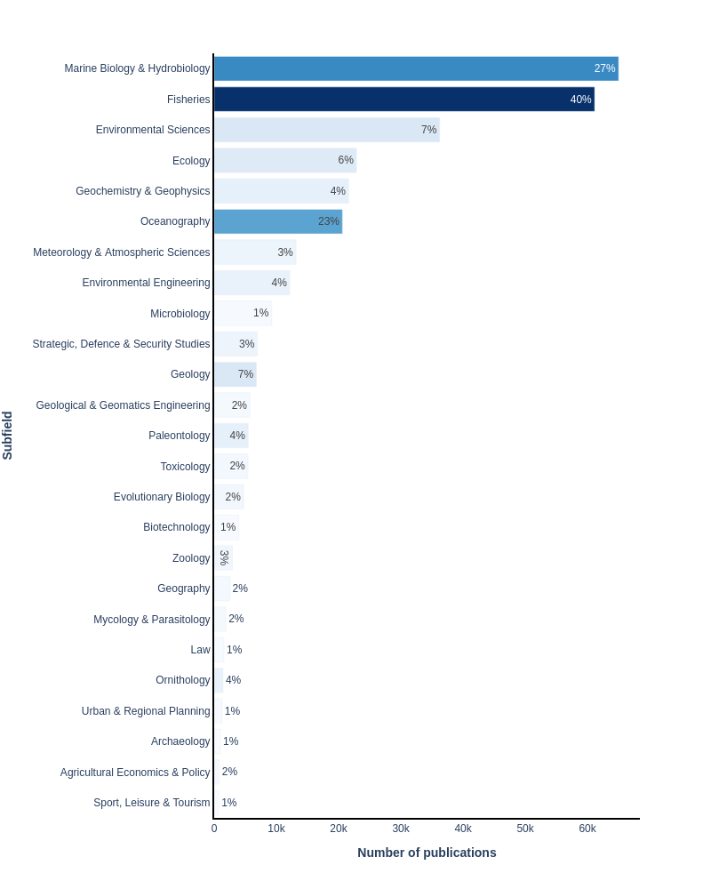

Figure 1. Top 25 subfields with the largest percentage of Scopus publication included in the publication set.

## Journals

In this section, we show how the publication set, captured by the query above, relates to scholarly journals. Journals are sorted in terms of their relevance using term frequency-inverse document frequency (TF-IDF). The horizontal bars are proportional to the number of publications contributed by the journal to the current publication set. The number alongside the horizontal bar is the proportion of the journal contributing to this publication set.

The articles on this topic are published most frequently in the following journals: *Aquaculture* (13,935 publications), *Marine Pollution Bulletin* (9,033), and *Aquaculture Research* (6,388).

Note, larger journals may not appear in the table below, as their SDG contribution may be relatively small compared to the size of the journal.

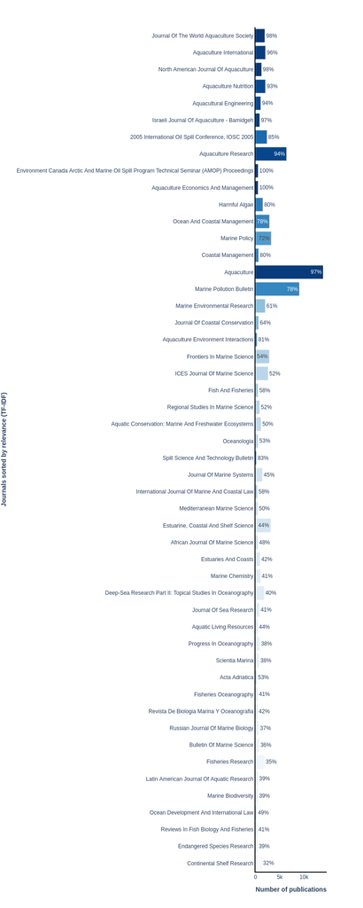

Figure 2. Top 50 journals, in terms of relevance (TF-IDF), for this publication set.

## Keywords

Elsevier’s [Scopus](https://www.scopus.com/search/form.uri?display=basic#basic) database of scientific literature, was used for the table below. The document types included in the data sets are journal articles, reviews, short surveys and conference papers, covering the period 1996–2022. We refer to these documents collectively as “publications” or “papers”.

In order to help better illustrate the content of this set of publications, indicators associated with the keywords most specific to this set (according to a TF-IDF score) are presented below.

|  | Term | # of papers with this term in the publication set | # of papers with this term in all of Scopus | Relevance (TF-IDF) | Percentage of Scopus |
| --- | --- | --- | --- | --- | --- |
| 1 | alexandrium | 2148 | 2343 | 18.7501 | 92 |
| 2 | marine reserve | 2495 | 2769 | 18.7126 | 90 |
| 3 | marine protected areas (mpas) | 1777 | 1980 | 18.7044 | 90 |
| 4 | marine reserves | 1471 | 1635 | 18.6897 | 90 |
| 5 | wetland restoration | 1732 | 1964 | 18.6703 | 88 |
| 6 | ocean acidification (oa) | 935 | 996 | 18.6619 | 94 |
| 7 | harmful algal blooms | 3606 | 4017 | 18.657 | 90 |
| 8 | enhanced biological phosphorus removal | 1195 | 1331 | 18.6493 | 90 |
| 9 | no-take | 1048 | 1156 | 18.6346 | 91 |
| 10 | marine conservation | 1723 | 1998 | 18.6288 | 86 |

[output cut: 990 more lines]